# PersonAlytics© User’s Guide

Stephen Tueller, Ty Ridenour, Derek Ramirez, Jessica Cance

2020-06-22

# 1 Introduction

## 1.1 Purpose

The purpose of this user’s guide is to illustrate how to use `PersonAlytics` to analyze

1. Single case time series data, also known as single subject or N-of-1 studies. Interrupted time series design designs can be used to introduce one (or more) interventions which results in two (or more) phases (e.g., pre-intervention and post-intervention).
2. Small sample intensive longitudinal design data.
3. Idiographic clinical trial data (ICT), which uses a single-case or small sample longitudinal data set where all participants experience two or more treatment phases (e.g., baseline and follow-up) and their data were modeled individually.

These three types of data are analyzed using longitudinal mixed effects models, also known as hierarchical linear models, multilevel models, latent growth curve models, or mixed method trajectory analysis.

While there are already several R packages to fit and compare Gaussian linear and nonlinear mixed-effects models, such as `nlme`: Linear and Nonlinear Mixed Effect Models (Pinheiro, Bates, DebRoy, & Sarkar, 2020) and `gamlss`: Generalized Additive Models for Location Scale and Shape (Rigby & Stasinopoulos, 2005), the purpose of the `PersonAlytics` package is to extend upon them by automating the following aspects of analyzing these types of data:

1. Model selection for detecting the shape of the trajectory of the dependent variable over time. Using a good fitting trajectory shape yields parameters that correspond to the underlying model-implied pattern of change and improve interpretability. Current options for the growth trajectory include polynomial growth (e.g., linear, quadratic, cubic, etc.) and piecewise growth (e.g., linear growth within each phase).
2. Model selection for detecting the pattern of temporal dependencies or autoregressive processes amongst the dependent variable using an appropriate time series model. Temporal dependency is captured as residual covariance. Getting a good fitting residual correlation model improves standard error estimation.
3. Analysis of mixed effects models in situations where the combination of predictors, outcomes, and/or individuals (i.e., in the case where individual level models are desired such as in personalized medicine) yields a number of analyses to unwieldy implement manually. This is especially true if the model selection process for the trajectory shape and the residual correlation model is conducted for each combination of predictors, outcomes, and/or individuals. High throughput analyses are achieved in `PersonAlytics` through parallelization. Jobs are split among two or more processors on a computer and run in parallel. Results are recombined at the end of the process. Included in `PersonAlytics` are options for the user to specify Type I error rate or False Discovery Rate (FDR) corrections. See the section title “High Throughput Examples” for details on implementing high throughput analyses.

## 1.2 Features

**High Throughput**. The `PersonAlytics` package automates the task of conducting large numbers of analyses using high throughput computation. A large number of analyses may be required when the combination of predictors, outcomes, and/or individuals yields a number of analyses to unwieldy implement manually.

**Parallelization**. High throughput analyses are achieved through parallelization. Jobs are split among two or more processors on a computer and are run in parallel to each other. Results are recombined at the end of the process.

## 1.3 Frequently Asked Question

1. Is missing data a problem? Missing data can be handled with the default estimation methods, i.e., REML (the restricted, or residual, or reduced) maximum likelihood approach, whih is a particular form of maximum likelihood estimation that bases estimates on a restrited likelihood function instead of on a maximum likelihood fit of all the information.
2. Is heterogeneous data struture a problem? No, individuals can have different number of observations or missing patterns.
3. The minimum number of time points need for the analysis? This depends on a few factors, including the number of variables, the complexity in the time series models, etc. Rules of thumb for any analysis can be applied, i.e., a more complex situation require a larger amount of timepoint to ensure sufficient power. Having at least 60 time points is normal for time series data, but we had achieve adequate results of univariate mixed effect models with number of time points as low as 20. That being said, our team is conducting simuation studies to evaluation the performance of models in relate to the number of observations.
4. Can the function include exogeneous variables and their interactions? Yes, multiple exogeneous variables can be included as covariates of the model, using `ivs` parameter, the interactions can be specified using `interactions` parameter (more details below). General guidelines of including covariates and their interactions apply to here. For example, possibility of collinearity that can bias the estimation of standard error, missingness in covariates that leads to lose of samples (and power), etc. We remind users to keep the number of covariates reasonaly low and select the list of covariates that carries theoretical implications.
5. Does the program support other types of response variables (e.g., binary, ordinal, counts data) or distributions? Yes, a variaty list of variables and distribution are available in consistent to what is offerred by `gamlss` (check under `gamlss.family` for a list of distribution available). Note that some of them require data transformation or rescaling prior to analysis, `PersonAlytics` provide function to automatically transform the data for you. For example, the `to01` is a function to rescale any variables to the [0,1] range so that the transformed data can be analyzed following a beta family. As part of the future simulation study plan, our team is evaluating the performance of models using response variables that follow ordinal or counts distributions.
6. What do I do if I obtain an error? Any initial trouble-shooting strategies?

Ensure your directories for your data are correct, and no other files are in this directory.

Ensure that the data is long format, in which repeated observations are stacked vertically, with the columns being variables and the rows containing the observations.

Ensure that all variables have variability (i.e., are not constant)??

Please cite the package (we really appreciate it): [Stephen Tueller, Ty Rinedour and Derek Ramirez (2020). PersonAlytics: Analytics for single-case and small N intensive longitudinal designs, idiographic clinical trials (ICT), and interrupted time series.. R package version 0.3.0.9. https://personalytics.rti.org/]

## 1.4 Working Example

**High Throughput Example 1: Migraine Triggers**. 346 migraine patients were followed for 90 days. They recorded information on 71 potential migraine and non-migraine headache triggers such as alcohol, weather, and exercise. Individual models were required to determine the five person-specific triggers with the largest effect size. Even though 90 time points is large, it was deemed to small to estimate all 71 trigger effects simultaneously, so trigger effects were estimated one at a time. The analysis required 346 patients X 2 outcomes X 71 triggers = 49,132 PersonAlytic runs.

**High Throughput Example 2: THC Metabolomics**. 17 patients participated in a two-phase design. The baseline phase had 2 hours of observation. The intervention was 25mg of THC and the intervention phase had 6 hours of observation. A total of 20 time points generated blood metabolomic data and outcomes including sleepiness, reaction time, memory, and behavior. The analysis required 18,023 chemical compounds (the metabolites) X 8 outcomes = 144,184 PersonAlytic runs.

# 2 The `PersonAlytic` framework

# 3 Installing `PersonAlytics`

*Note. It is assumed that the user has basic familiarity with `R`. If needed, there are numerous online tutorials to help the user become familiar with `R` (e.g., https://r4ds.had.co.nz).* That said, we will define a few key terms here that are used throughout this document:

- Console: This is the part of `R` that can be used interactively. Code can be typed in and results will be displayed in the console.
- Object: Anything saved to `R`’s memory. For example, if you type `x <- 1`in the console, you have created an object `x` which has a value of 1. If you then type `x` into the console and press enter, `x`’s value of 1 will be printed to the console.
- Environment: This is `R`’s current “active memory” that stores all of the objects you have created or loaded into `R`. Type `ls()` to view them all.
- Function: An `R` object that takes in other `R` objects (called parameters), performs some computation on them, and may (or may not) return a new object. A simple example is the `mean()` function. The parameter is some numeric data called a vector such as `x <- c(1,2,3)`. Passing `x` to the mean function `mean(x)` returns a value of 2.
- Parameter: Named `R` objects that are passed to an `R` function.
- R documentation: `R` functions, including the functions of `PersonAlytics` are documented. This includes a descriptions of their parameters and how they should be used. The documentation can be accessed by typing a questions mark followed by the name of the function (e.g., `?mean`).
- Working directory: The directory on your computer where `R` is “working”. An `R` function may return objects to the environment or they may save results to the working directory. To see the current working directory type ‘getwd()’.

First the user must install `R`, available at https://cran.r-project.org/. It is also suggested that the user install a modern code editor such as Rstudio available at `https://www.rstudio.com/`. It is assumed that the reader is familiar with basic `R` use. If needed, an internet search will provide tutorials to help the user become familiar with R. The `RTools` software (which is not an `R` package) should be also installed from https://cran.r-project.org/bin/windows/Rtools/ prior to installing `Personalytics`.

Installing `PersonAlytics` is done using the `install_github` function of the `devtools` package. First install `devtools` using

```r
install.packages('devtools')
```

After re-starting R, type the following into the console:

```r
devtools::install_github("ICTatRTI/PersonAlytics", build_opts = c("--no-resave-data", "--no-manual"), build_vignettes = TRUE)
```

The `install_github` function may give the user the option to update other R packages needed by `PersonAlytics` that are already installed by the user. Unless the user is experienced with R package versions and updates, it is recommended that the user ignore this step and press enter without selecting an option to update packages. If the user does decide to update packages and runs into an error, they may need to restart `R`, manually update the package in the error message, and then rerun the `install_github` command. If a newer version of a package is required by `PersonAlytics` the `install_github` will attempt to install it.

Once `install_github` starts running, it will install all the other `R` packages required by `PersonAlytics` if the user does not already have them. Building of the vignettes (such as this one) can take several minutes.

# 4 Starting `PersonAlytics`

Now we can load `PersonAlytics` using

```r
library(PersonAlytics)
```

After loading all of the R packages that `PersonAlytics` requires, you’ll see instructions to bring up this document by typing the following in the console (assuming you left `build_vignettes = TRUE` when installing `PersonAlytics`):

```r
vignette("PersonAlytics_Users_Guide")
```

*Note: If you are using Rstudio the R documentation, such as accessed by typing `?PersonAlytic` in the console, will appear under the “Help” tab. Included in most documentation pages is an example section. If you highlight code in the example and press ctrl+enter, than code will run in the R console. Typing `vignette("PersonAlytics_Users_Guide")` will bring up this user’s guide in the “Viewer” tab. Although highlighted code cannot be run from the viewer, you can copy/paste from the guide into the console to run the examples herein.*

# 5 Basic `PersonAlytics` Use

The `PersonAlytic()` function is the primary user interface for the `PersonAlytics` package and the user can access the documentation for `PersonAlytic()` by typing

```r
?PersonAlytic
```

## 5.1 The OvaryICT Data

We will illustrate the basic parameters of the `PersonAlytic()` function using a data set called OvaryICT, which contains data modified from the Ovary data in the `nlme` package. A description is available by typing `?Ovary` in the `R` console. The `OvaryICT` data set was modified to include a phase variable to represent the structure of an ICT. A description of the modifications are available by typing `?OvaryICT` in the `R` console. The `OvaryICT` data come with the `PersonAlytics` package and are used in most of the documentation examples. A phase variable is an essential component of an ICT. A typical phase variable represents pre- and post-treatment phases of a study, and more that two phases are an option in `PersonAlytics`.

|  | Mare | Time | follicles | Phase | Phase2 | Target1 | Target2 | Target3 | Target4 | Target5 | Target6 |
| --- | --- | --- | --- | --- | --- | --- | --- | --- | --- | --- | --- |
| 83 | 1 | -0.14 | 9 | 0 | 1 | 3 | 3 | 4 | -0.53 | 0.18 | 0.74 |
| 84 | 1 | -0.09 | 9 | 0 | 1 | 3 | 1 | 4 | -1.37 | 1.34 | 0.63 |
| 85 | 1 | -0.05 | 7 | 0 | 1 | 1 | 4 | 4 | -2.21 | 1.20 | 1.24 |
| 86 | 1 | 0.00 | 6 | 0 | 1 | 4 | 2 | 4 | 1.82 | 0.87 | 0.23 |
| 87 | 1 | 0.05 | 7 | 0 | 1 | 1 | 1 | 2 | -0.65 | -0.12 | -0.31 |
| 88 | 1 | 0.09 | 6 | 0 | 1 | 4 | 3 | 4 | -0.28 | 0.34 | 1.50 |

## 5.2 Required `PersonAlytics` Parameters

The four required parameters for `PersonAlytic()` are

1. `data`: the name of the user’s data set. This data needs to have been read into R prior to using `PersonAlytic()`. A web search can be used to learn how to read in multiple types of data into R, including (but not limited to) csv, xlsx, sas, stata, spss, and most database formats. The data must be structured in ‘long format’ where time points are repeated within individual as was illustrated above for the `OvaryICT` data. The examples in this user’s guide are based on the `OvaryICT` data.
2. `ids`: the name of the identification variable for individuals. This must be a quoted variable name matching the user’s ID variable in the data set that the user provided to the parameter `data`.
3. `dvs`: the name of the dependent variable. This must be a quoted variable name matching the user’s dependent variable in the data set that the user provided to the parameter `data`. If the user has multiple dependent variables, `PersonAlytics` will iterate over them one at a time. Multiple dependent variables are specified as a character list, e.g., `dvs=list('dv1', 'dv2', etc.)`. This is a high throughput option that will be described in more detail in the section titled “High Throughput Options”.
4. `time`: the name of the time variable. This must be a quoted variable name matching the user’s dependent variable in the data set that the user provided to the parameter `data`.

**list()**. In `R`, a list is a collection of variables or `R` objects that may or may not be of the same type. For example, a list might all be character strings, as is the case with `dvs=list('dv1', 'dv2', etc.)`. In other situations, a list may mix data frames, character vectors, or other data types.

We now illustrate using the four basic parameters with the `OvaryICT` data. This example also includes setting `autoSelect=NULL`, which turns off automated model comparisons for selecting the trajectory shape and residual correlation structure, options that are discussed in the “Autoselection” section.

```r
eg_required <- PersonAlytic(data=OvaryICT,
                ids="Mare",
                dvs="follicles",
                time="Time",
                autoSelect=NULL)
```

It is important to assign the results of a call to `PersonAlytic` to an R object. In the example above, the object is named `eg_required`. If the user neglects to assign the results to an R object, minimal output will be printed to the screen and the remaining results will be lost. If high throughput is initialized by including more than one dependent variable, including more than one target independent variables (see parameter `target_ivs` below), or if requesting individual models (see parameter `individual_mods` below), the resulting object is a `data.frame` concatenating results across the parameters submitted to the high throughput run. Reading the output is detailed in the section titled “Reading `PersonAlytics` Output”.

## 5.3 Commonly Used Optional `PersonAlytics` Parameters

In this section we introduce commonly used optional `PersonAlytics` parameters.

### 5.3.1 The `phase` variable

The `phase` parameter specifies the phase variable. While a phase variable is required for an ICT, the `PersonAlytic()` function does not require a phase variable to allow for other analyses such as time series analyses and small sample intensive longitudinal data. The `phase` parameter must be a quoted variable name matching phase variable in the data set that the user provided to the parameter `data`.

```r
eg_phase <- PersonAlytic(data=OvaryICT,
                ids="Mare",
                dvs="follicles",
                phase="Phase",
                time="Time",
                autoSelect=NULL)
```

By default, the phase by time interaction will be included in the model. However, if the parameter `alignPhase=piecewise`, a piecewise growth model is fit instead and the time by phase interaction will be dropped if it model fails to converge with the interaction term. The ‘alignPhase’ parameter is described in the section on other optional parameters.

### 5.3.2 The Shape of the Trajectory

By default, a linear growth model is fit to the data (`time_power=1`). Any integer may be supplied to `time_power` to specify the corresponding trajectory shape (e.g., linear, quadratic, cubic, etc.). Alternatively, `PersonAlytics` can automatically detect the order for time using the `TO` parameter of the `autoSelect` parameter as described in the section on autoselection.

Here is an example of a quadratic growth trajectory specified using `time_power=2`:

```r
eg_time_power <- PersonAlytic(output="MyResults",
                data=OvaryICT,
                ids="Mare",
                dvs="follicles",
                phase="Phase",
                time="Time",
                time_power=2,
                autoSelect=NULL)
```

### 5.3.3 Residual Correlation Structure

The residual autocorrelation structure can be specified by the user using the `correlation` parameter. The `correlation` parameter default is NULL, corresponding to no within-person temporal auto-correlations.

Any option listed in the `?corStruct` documentation of the `nlme` package can be specified (see also the correlation parameter in `?lme`). When specifying a correlation structure, the parameters P and Q must be specified explicitly and the entire correlation structure must be in quotes. Alternatively, PersonAlytics can automatically detect the values for P and Q for an ARMA(P,Q) model using the AR option of the `autoSelect` parameter as described below.

Here is an example specifying an ARMA(3,4) residual correlation structure:

```r
eg_correlation <- PersonAlytic(output="MyResults",
                data=OvaryICT,
                ids="Mare",
                dvs="follicles",
                phase="Phase",
                time="Time",
                correlation="corARMA(p=3,q=4)",
                autoSelect=NULL)
```

Note that the parameters `p` and `q` must be lower case and the entire correlation structure must be in quotes. Alternatively, `PersonAlytics` can perform automatic model selection for the values for `p` and `q` in an `ARMA(p,q)` model using the `AR` parameter of the `autoSelect` parameter as described in the section on autoselection (Pinheiro & Bates, 2000).

*Note: For users unfamiliar with residual correlation structures (or other features of the `nlme` package), a helpful reference is the book “Mixed-Effects Models in S and S-PLUS” by Pinheiro and Bates (2000).*

### 5.3.4 Distributional Assumptions

By default, a linear mixed effects model is fit assuming a normal distribution for the outcome (or, more precisely, for the residuals). If the `package` parameter is set to `'gamlss'`, the `family` parameter can be used to specify any of the distributions available in the `?gamlss.family` package. Once a model is fit, the plot function can be used to examine the residuals if a single model is fit (i.e., `dvs` has only one variable, `target_ivs` is not used, and `individual_mods` is FALSE).

Here is an example of a normal model fit using `gamlss`.

```r
eg_normal <- PersonAlytic(data=OvaryICT,
                ids="Mare",
                dvs="follicles",
                phase="Phase",
                time="Time",
                family=NO(),
                package="gamlss",
                autoSelect=NULL)
```

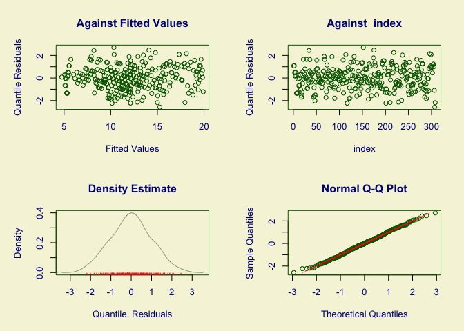

```
##        Summary of the Quantile Residuals
##                            mean   =  4.314702e-17
##                        variance   =  1.003257
##                coef. of skewness  =  0.02660023
##                coef. of kurtosis  =  2.684892
## Filliben correlation coefficient  =  0.998804
```

```r
plot(eg_normal)
```

Here, the above example is repeated, this time using a Weibull Type 2 distribution:

```r
eg_weibull2 <- PersonAlytic(data=OvaryICT,
                ids="Mare",
                dvs="follicles",
                phase="Phase",
                time="Time",
                family=WEI2(),
                package="gamlss",
                autoSelect=NULL)
```

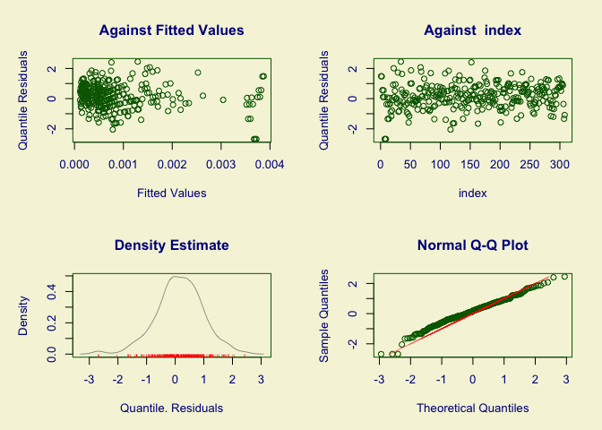

```
##        Summary of the Quantile Residuals
##                            mean   =  0.1554844
##                        variance   =  0.680279
##                coef. of skewness  =  -0.2875389
##                coef. of kurtosis  =  3.794029
## Filliben correlation coefficient  =  0.9942695
```

```r
plot(eg_weibull2)
```

Alternatively, the `PersonAlytic()` function can automatically select the best fitting distribution using the `DIST` parameter described in the autoselection section below.

# 6 High Throughput Options

High throughput automation is invoked by any combination of the following:

1. Multiple dependent variables, which are analyzed one at a time.
2. Multiple target independent variables, which are included one at a time. This is often necessary when there are too many independent variables to be analyzed simultaneously as illustrated in the two high throughput examples (migraine triggers and THC metabolomics).
3. Individual level models, in which separate models are fit for each participant in the data set. This is necessary when it is unrealistic to expect each individual to have the same residual correlation structure or if it is expected that each participant will have a unique set of target independent variables that have the biggest effects on their outcomes as is the case in the migraine triggers example.

## 6.1 Multiple Dependent Variables

Here we illustrate a high throughput example by first creating two additional outcomes and fitting a basic growth model to each outcome. Note that creating variables that are the square and the root of the outcome is not advised unless the user has substantive reasons to do so, this is simply for illustration purposes:

```r
OvaryICT$follicles2 <- OvaryICT$follicles^2
OvaryICT$folliclesr <- sqrt(OvaryICT$follicles2)
eg_htp <- PersonAlytic(output="htp_example",
                data=OvaryICT,
                ids="Mare",
                dvs=list("follicles", "follicles2", "folliclesr"),
                phase="Phase",
                time="Time",
                autoSelect=NULL)
```

```
##
##
## Model fitting starting...
```

```
##
##
## Model fitting took:
##  Time difference of 4.959008 secs.
```

## 6.2 Independent Variables and Target Independent Variables

Independent, or predictor, variables can be added using the `ivs` parameter. This might be a grouping variables (e.g., treatment/control) or demographic variable (e.g., age or sex). If there are more than one dependent (or outcome) variables in `dvs`, the variables in `ivs` will be included as predictors for each dependent variable.

```r
eg_ivs <- PersonAlytic(output="MyResults",
                data=OvaryICT,
                ids="Mare",
                dvs="follicles",
                phase="Phase",
                time="Time",
                ivs=list("Target1", "Target2", "Target3"),
                autoSelect=NULL)
```

If the user wishes to iterate over multiple independent variables one at a time, use `target_ivs`. This is a high throughput option.

```r
eg_target_ivs <- PersonAlytic(output="MyResults",
                data=OvaryICT,
                ids="Mare",
                dvs="follicles",
                phase="Phase",
                time="Time",
                target_ivs=list("Target4", "Target5", "Target6"),
                autoSelect=NULL)
```

```
##
##
## Fitting models of the dependent variable `follicles` for 11 cases in `Mare`
##  and for 3 target independent variables in `target_ivs`.
```

```
##
##
## Model fitting for the dependent variable `follicles` took:
##  Time difference of 4.29715 secs.
```

If the user has some independent variables that should be in every model and some that should be added one at a time, both `ivs` and `target_ivs` can be used. Here, Target1-3 will be included in every model, but Target4-6 will be added one at a time.

```r
eg_target_ivs2 <- PersonAlytic(output="MyResults",
                data=OvaryICT,
                ids="Mare",
                dvs="follicles",
                phase="Phase",
                time="Time",
                ivs=list("Target1", "Target2", "Target3"),
                target_ivs=list("Target4", "Target5", "Target6"),
                autoSelect=NULL)
```

```
##
##
## Fitting models of the dependent variable `follicles` for 11 cases in `Mare`
##  and for 3 target independent variables in `target_ivs`.
```

```
##
##
## Model fitting for the dependent variable `follicles` took:
##  Time difference of 4.613324 secs.
```

If the user wants variables to be dummy coded, the user should first specify this in the data set. For example, this code specifies that the `Target1` variable should be treated as a categorical variable and dummy coded in any future analyses:

```r
OvaryICT$Target1 <- factor(OvaryICT$Target1)
```

For more information about factors in `R`, users can read the documentation by typing `?factor` in the console or conducting an internet search for tutorials in factors in R.

The `interactions` parameter can be used to specify pairs of independent variables to be included in interaction terms. Main effects for all variables in the interaction terms will be estimated even if they are not listed in the `ivs` or `target_ivs` parameter as shown in this example.

```r
eg_interactions <- PersonAlytic(output="MyResults",
                data=OvaryICT,
                ids="Mare",
                dvs="follicles",
                phase="Phase",
                time="Time",
                interactions=list(c("Target1", "Target2"), c("Target1", "Target3"),
                         c("Target2", "Target3")),
                autoSelect=NULL)
```

## 6.3 Individual Level Models

`PersonAlytics` can automate the task of fitting individual models to each case in the data set. This is useful for applications such as individualized medicine such as the migraine data example in the introduction. In that example, the investigators wanted to find the most potent migraine triggers for each patient (an individual level question), not the triggers that were most common across all patients (a sample level question). The option of fitting individual models is enabled by setting `individual_mods=TRUE`. The resulting output will be the `data.frame` saved to the assigned object in your R session. This will also be saved to a `csv` file named using the `output` parameter. In each of these two equivalent forms of output, each row corresponds to a separate case.

## 6.4 Combinations of `dvs`, `target_ivs` and `individuals_mods`

Any combination of `dvs`, `target_ivs` and `individuals_mods` can be specified. The migraine triggers example uses all three types of variables, and the THC metabolomics example uses both target independent variables (the metabolites) and dependent variables (the 8 outcomes). The `PersonAlytic` function sets up the parallelization to minimize redundant operations depending on which combination of high throughput parameters the user requests.

# 7 Reading `PersonAlytics` Output

The parameter `output` is a character string that is used to name a file for saving output. If left `NULL`, the default is ‘PersonAlytic_Output’. Do not give a file extension, these will be added automatically depending on whether a single analysis was run (yielding a .txt file) or high throughput parameters were invoked (yielding a .csv file).

## 7.1 Single Analysis Output

Here we fit the same model using `nlme` and `gamlss` and illustrate options for viewing and manipulating the output. Documentation for these `R` packages can be obtained by typing

```r
library(nlme)
?lme
library(gamlss)
?gamlss
```

The `nlme` package implements the linear (normal) mixed effects model using the `lme()` function. The `gamlss` package generalizes the mixed effects model for over 80 non-normal distributions. Typing `?gamlss.family` in the console will bring up the full list of distributions.

In `PersonAlytics`, using the `package` parameter can be used to specify the `gamlss` package instead of `nlme`, which is the default. When `package="gamlss"`, the `family` parameter is used to specify the distribution using the “R names” column in the documentation for `?gamlss.family` (e.g., `family=BE()` for beta regression). The `family` parameter is described in more detail in the section titled “Distributional Assumptions” above. The default distribution assumed when using `package="gamlss"` is the normal distribution (i.e., `family=NO()`).

In the current example we first run the model using `package="nlme"`. Since this is the default, we do not need to explicitly specify the `package` parameter though we do so in this example. The output will be saved the the R object `eg_nlme` for further use inside the R console. In addition, `output="nlme_example"` will create a file in the working directory named ‘nlme_example.txt’. If the user are unsure what the user’s current working directory is, type `getwd()` into the R console. A full path using forward slashes ‘/’ instead of backslashes ’\' can also be used. For example, `output='C:/MyResults'`. For convenience, we will also turn off the `autoSelect` parameter by setting it to `NULL`. The `autoSelect` parameter is discussed in detail below.

```r
eg_nlme <- PersonAlytic(output="nlme_example",
                data=OvaryICT,
                ids="Mare",
                dvs="follicles",
                phase="Phase",
                time="Time",
                package="nlme",
                autoSelect=NULL)
```

Then we run the same model using `package="gamlss"`. The output will be saved the the R object `eg_gamlss` for further use inside the R console. In addition, `output="gamlss_example"` will create a file in the working directory named ‘gamlss_example.txt’.

```r
eg_gamlss <- PersonAlytic(output="gamlss_example",
                data=OvaryICT,
                ids="Mare",
                dvs="follicles",
                phase="Phase",
                time="Time",
                package="gamlss",
                autoSelect=NULL)
```

In these examples, the R object `eg_nlme` is a class `lme` object, and the R object `eg_gamlss` is a class `gamlss` object.

```r
class(eg_nlme)
```

```
## [1] "lme"
```

```r
class(eg_gamlss)
```

```
## [1] "gamlss" "gam"    "glm"    "lm"
```

Both `lme` and `gamlss` objects have a `summary()` method which prints detailed results to the R console. For the `nlme` example we get the following.

```r
summary(eg_nlme)
```

```
Linear mixed-effects model fit by REML
 Data: tempData
       AIC      BIC    logLik
  1670.449 1700.185 -827.2244

Random effects:
 Formula: ~Time | Mare
 Structure: General positive-definite, Log-Cholesky parametrization
            StdDev   Corr
(Intercept) 2.751709 (Intr)
Time        3.871676 -0.202
Residual    3.317972

Fixed effects: follicles ~ Time * Phase
               Value Std.Error  DF   t-value p-value
(Intercept) 10.66163 0.9016267 294 11.824883  0.0000
Time        -0.86898 1.7667760 294 -0.491845  0.6232
Phase       10.97209 1.3126329 294  8.358845  0.0000
Time:Phase  -8.64385 1.9742483 294 -4.378299  0.0000
 Correlation:
           (Intr) Time   Phase
Time       -0.318
Phase      -0.105  0.135
Time:Phase  0.175 -0.504 -0.817

Standardized Within-Group Residuals:
        Min          Q1         Med          Q3         Max
-2.49764683 -0.65159342 -0.01330142  0.61976543  2.61092061

Number of Observations: 308
Number of Groups: 11
```

The fixed effects results in the section titled ‘Fixed Effects’ is what gets saved to the file ‘nlme_example.txt’. For the `gamlss` example we get the following:

```r
summary(eg_gamlss)
```

```
Family:  c("NO", "Normal")

Call:  gamlss::gamlss(formula = self$formula, sigma.formula = sigma.formula,
    family = currentFamily, data = tempData, control = ctrl)

Fitting method: RS()

------------------------------------------------------------------
Mu link function:  identity
Mu Coefficients:
            Estimate Std. Error t value Pr(>|t|)
(Intercept)  10.6898     0.3404  31.402  < 2e-16 ***
Time         -0.8637     1.2787  -0.675      0.5
Phase        10.9725     1.2654   8.671 3.28e-16 ***
Time:Phase   -8.6439     1.9033  -4.541 8.25e-06 ***
---
Signif. codes:  0 '***' 0.001 '**' 0.01 '*' 0.05 '.' 0.1 ' ' 1

------------------------------------------------------------------
Sigma link function:  log
Sigma Coefficients:
            Estimate Std. Error t value Pr(>|t|)
(Intercept)  1.16333    0.04029   28.87   <2e-16 ***
---
Signif. codes:  0 '***' 0.001 '**' 0.01 '*' 0.05 '.' 0.1 ' ' 1

------------------------------------------------------------------
NOTE: Additive smoothing terms exist in the formulas:
 i) Std. Error for smoothers are for the linear effect only.
ii) Std. Error for the linear terms may not be reliable.
------------------------------------------------------------------
No. of observations in the fit:  308
Degrees of Freedom for the fit:  23.39381
      Residual Deg. of Freedom:  284.6062
                      at cycle:  2

Global Deviance:     1590.679
            AIC:     1637.467
            SBC:     1724.728
```

The fixed effects results in the section titled ‘Mu Coefficients’ and the variance coefficients in the section titled ‘Sigma Coefficients’ is what gets saved to the file ‘gamlss_example.txt’.

It is beyond the scope of this document to detail the differences between the `nlme` and `gamlss` approaches, but we will highlight one important difference. Notice that the parameter estimates in the ‘Value’ column of the ‘Fixed Effects’ section of the `eg_nlme` output and the ‘Estimate’ column of the ‘Mu Coefficients’ section of the `eg_gamlss` output are very similar. However, the standard errors are of the `gamlss` model are lower. This is because the `gamlss` approach models not only the mean, but also the variance. If there is any heteroscedasticity of variance, the `gamlss` results will consequently have lower standard errors than the `nlme` results. In the `gamlss` output, the variance parameter(s) are in the ‘Sigma Coefficients’ section.

**Heteroscedasticity**. heteroscedasticity occurs in data when the variability of the dependent variable is unequal across the range of values of one (or more) predictors. In this example, the the variance of y gets larger as values of the predictor x get larger.

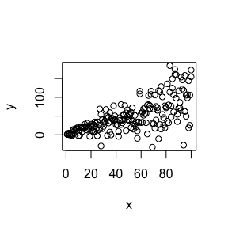

## 7.2 Multiple Analysis/High Throughput Analysis Output

For this section we will reuse the “Multiple Dependent Variables” example of the “High Throughput Options” section:

```r
OvaryICT$follicles2 <- OvaryICT$follicles^2
OvaryICT$folliclesr <- sqrt(OvaryICT$follicles2)
eg_htp <- PersonAlytic(output="htp_example",
                data=OvaryICT,
                ids="Mare",
                dvs=list("follicles", "follicles2", "folliclesr"),
                phase="Phase",
                time="Time",
                autoSelect=NULL)
```

Here are all the column names for the current example:

```
 [1] "Mare"                   "ids"                    "dv"
 [4] "time"                   "phase"                  "ivs"
 [7] "target_iv"              "interactions"           "time_power"
[10] "alignPhase"             "correlation"            "family"
[13] "gamlss.family"          "standardize"            "method"
[16] "package"                "Personalytics"          "Date_Time"
[19] "N_participants"         "N_time_points"          "N_time_points_complete"
[22] "dvVariance"             "timeVariance"           "ivVariance"
[25] "target_ivVariance"      "converge"               "estimator"
[28] "analyzed_N"             "call"                   "wasLRTrun"
[31] "targ_ivs_lrt_pvalue"    "fixed"                  "random"
[34] "formula"                "correlation0"           "directory"
[37] "date"                   "statName1"              "statValue1"
[40] "statName2"              "statValue2"             "statName3"
[43] "statValue3"             "X.Intercept..Value"     "X.Intercept..Std.Error"
[46] "X.Intercept..DF"        "X.Intercept..t.value"   "X.Intercept..p.value"
[49] "Time.Value"             "Time.Std.Error"         "Time.DF"
[52] "Time.t.value"           "Time.p.value"           "Phase.Value"
[55] "Phase.Std.Error"        "Phase.DF"               "Phase.t.value"
[58] "Phase.p.value"          "Time.Phase.Value"       "Time.Phase.Std.Error"
[61] "Time.Phase.DF"          "Time.Phase.t.value"     "Time.Phase.p.value"
```

# 8 Autoselection of the Residual Autocorrelation Structure, Time Order, and Dependent Variable Distribution

The Autoselection parameters automate the tedious process of conducting ML model comparisons to determine any of three parameters described in this section. The value `NULL` (`autoSelect=NULL`), or an empty list (`autoSelect=list()`) turns all options off. Leaving any parameter out of the list will turn that parameter off (e.g., `autoSelect=list(TO=list(polyMax=3))` will only implement Autoselection of the time order). The default is `autoSelect=list(AR = list(P = 3, Q = 3), TO = list(polyMax = 3), DIST = list())`. As noted above, a list in `R` is a collection of objects (or variables) that need not be of the same type. In this example,

- `autoSelect` is a list that has length 3.
- The first object in `autoSelect` is another list, `AR = list(P = 3, Q = 3)`.
  - `AR` has length 2
  - The first value is named `P` and has a value of 3.
  - The second value is named `Q` and also have a value of 3.
- The second object in `autoSelect` is also a list, `TO = list(polyMax = 3)`. In this example `TO` has length 1 containing a value named `polyMax` with a value of 3.
- The final object in `autoSelect` is a list `DIST = list()`. `DIST` has length 0, i.e., it is an empty list.

This preceding discussion is meant to familiarize new `R` users with lists, and `AR`, `TO`, and `DIST` are explained in more detail in the remainder of this section.

## 8.1 Residual Correlation Structure `AR`

`AR` is the autoregressive moving-average (ARMA) order of the residual correlation structure. Determining a good fitting correlation structure will provide more accurate standard errors. The default, `AR=list(P=3, Q=3)` will search all combinations of `p=c(0,1,2,3)` and `q=c(0,1,2,3)`, as well as the default with no within-group correlations (`correlation=NULL`), for the best fitting ARMA correlation structure. This is done with a fit index instead of ML likelihood ratio tests (LRT) because not all ARMA models are nested (a requirement of the LRT). The fit index that will be used is set using the `whichIC` parameter with options `BIC` or `AIC`. It is beyond the scope of this document to discuss the LRT or choosing between BIC and AIC, and users should leave the default as `BIC` until they have familiarized themselves with the differences between them. If $n=1$ or `individual_mods=TRUE`, correlation model selection is implemented using the `auto.arima` function of the `forecast` package. See `?auto.arima`.

Here is an example of using the `AR` parameter of the `autoSelect` parameter without the `TO` or `DIST` parameters:

```r
eg_autoSelect_AR <- PersonAlytic(data=OvaryICT,
                ids="Mare",
                dvs="follicles",
                phase="Phase",
                time="Time",
                method="ML",
                package="gamlss",
                autoSelect = list(AR=list(P=3, Q=2)))
```

```
##
##
## PersonAlytics: Automatic detection of the
## residual correlation structure starting...
```

```
##
## Automatic detection of the residual
## correlation structure took: Time difference of 11.5093 secs.
```

```
##
## The best correlation structure among those tested is nlme::corARMA(p=0,q=2)
```

The result is that the best correlation structure is nlme::corARMA(p=0,q=2), an ARMA model with an autoregressive (AR) order of 0 and a moving average (MA) order of 2.

## 8.2 The Trajectory Shape `TO`

This parameter sets the shape of the trajectory using the polynomial order of the time/outcome relationship. Determining a good shape for the trajectory over time helps with model interpretation. Automatic detection is implemented using likelihood ratio test of the model with $Y=Time + Time^2 + \dots + Time^{O}$ vs. $Y=Time + Time^2 + \dots + Time^{O \mbox{-} 1}$ where $O$ is the polynomial order of the time variable. The default is `TO=list(polyMax=3)`, where `polyMax` is the largest values of $O$ to test. As noted above, `time_power` is used when the user wants to specify a value for $O$, and doing so requires setting `TO=list()` or leaving it out of the `autoSelect` parameter.

Here is an example of using the `TO` parameter of the `autoSelect` parameter, setting the maximum polynomial order of the time variable to 4 without the `AR` or `DIST` parameters:

```r
eg_autoSelect_TO <- PersonAlytic(data=OvaryICT,
                ids="Mare",
                dvs="follicles",
                phase="Phase",
                time="Time",
                method="ML",
                package="gamlss",
                autoSelect = list(TO=list(polyMax=4)))
```

```
##
##
## PersonAlytics: Automatic detection of the
## time/outcome relationship starting...
```

```
##
## Automatic detection of the time/outcome
## relationship took: Time difference of 40.67288 secs.
##
## The best polynomial order for time from 1 to 4 was 3
```

The result is that the best polynomial order is 3, which is a cubic growth model.

An alternative to using a polynomial order for time is to approximate the trajectory shape using a separate linear model within each of the phases. This can be set using the `piecewise` parameter of the `alignPhase` parameter as described below.

## 8.3 Dependent Variable Distributional Assumption `DIST`

The `DIST` parameter autoselect the best fitting distribution of the dependent variable using the `fitDist` function of the `gamlss` package. To see all of the available options, type

```r
?gamlss.family
```

into the console. The default is `DIST=list()`. To turn off Autoselection of the best fitting dependent variable distribution, remove `DIST` from the `autoSelect` list.

Here is an example of using the `DIST` parameter of the `autoSelect` parameter without the `TO` or `AR` parameters:

```r
eg_autoSelect_DIST <- PersonAlytic(data=OvaryICT,
                ids="Mare",
                dvs="follicles",
                phase="Phase",
                time="Time",
                package="gamlss",
                autoSelect = list(DIST=list()))
```

```
##
## The variable follicles has the following characteristics:
## Integer     :  TRUE
## Binary      :  FALSE
## Proportion  :  FALSE
## Positive    :  TRUE
## Multinomial :  FALSE  (integer with >2 & <= 5 categories)
## Count       :  TRUE  (positive integer)
## Continuous  :  FALSE  (non-integer)
##
## Error in solve.default(oout$hessian) :
##   Lapack routine dgesv: system is exactly singular: U[4,4] = 0
## Error in solve.default(oout$hessian) :
##   Lapack routine dgesv: system is exactly singular: U[3,3] = 0
## Error in solve.default(oout$hessian) :
##   Lapack routine dgesv: system is exactly singular: U[4,4] = 0
## Error in solve.default(oout$hessian) :
##   Lapack routine dgesv: system is exactly singular: U[4,4] = 0
##
## Family:  c("WEI2", "Weibull type 2")
## Fitting method: "nlminb"
##
## Call:  gamlssML(formula = y, family = DIST[i], data = sys.parent())
##
## Mu Coefficients:
## [1]  -6.686
## Sigma Coefficients:
## [1]  0.9418
##
##  Degrees of Freedom for the fit: 2 Residual Deg. of Freedom   306
## Global Deviance:     1856.73
##             AIC:     1860.73
##             SBC:     1868.19
```

```
##
## To explore this distribution install `gamlss.demo` and type
##
## dev.new()
## gamlss.demo::demoDist()
##
## into the console, find your distribution, and use the
## slider bars to select the parameters printed above
## (mu, sigma, nu, and tau).
```

```
##
## Descriptive statistics by phase:
##          mean median   sd skewness kurtosis
## 0       10.52     10 4.07     0.23     2.92
## 1       13.65     13 5.47     0.12     2.00
## OverAll 12.04     12 5.04     0.38     2.54
```

The output above is printed to the console, and users should focus on the following parts:

- The first section titled “The variable follicles has the following characteristics” describes the variable. If any of these appear incorrect, check your data.
- The next section may contain errors. This occur when distributions are fit to the dependent variable but do not converge. These distributions will be removed from consideration.
- The section starting with “Family:” returns the best fitting distribution. In this example, the best fitting distribution is the “Weibull type 2” distribution. The resulting object `eg_autoSelect_DIST` is a `gamlss` object fit using the Weibull type 2 distribution. The remaining output gives parameter estimates and descriptive statistics for the best fitting distribution.

# 9 Other Optional `PersonAlytic()` Parameters

## 9.1 Subgroup Analysis

The `subgroup` parameter can be used to fit the model to a subset of the data. A logical (`TRUE`/`FALSE`) or binary (0/1) vector can be used to specify which cases to use.

Here is an example restricting the analysis to the first 5 mares in the `OvaryICT` data set. The code `OvaryICT$Mare<6` creates a logical vector which is true if the mare id is less than 6:

```r
eg_subgroup <- PersonAlytic(data=OvaryICT,
                ids="Mare",
                dvs="follicles",
                phase="Phase",
                time="Time",
                subgroup=OvaryICT$Mare<6,
                autoSelect=NULL)
```

## 9.2 Variable Standardization

Variable standardization (mean zero and unit variance) is facilitated using the `standardize` parameter which is a list with three parameters that can be set to `TRUE` or `FALSE` (the default for all three is `FALSE`):

- `dv`: if set to `TRUE`, the dependent variable is standardized. If there are multiple dependent variables in `dvs`, each dependent variable will be standardized.
- `ivs`: if set to `TRUE`, the the independent variables in `ivs` and `target_ivs` are standardized. This is useful for determining which target independent variable has the largest effect size since standardization put their respective effect sizes on the same scale. All continuous variables should be standardized.
- `byids`: if set to `TRUE`, standardization is done within each individual. This parameter should be set to `TRUE` if `individual_mods=TRUE` (`individual_mods` parameter is discussed in the section on high throughput options).

Here is an example where the target independent variables are standardized:

```r
eg_standardize <- PersonAlytic(data=OvaryICT,
                ids="Mare",
                dvs="follicles",
                phase="Phase",
                time="Time",
                target_ivs=list("Target1", "Target2", "Target3"),
                standardize=list(dv=FALSE, ivs=TRUE, byids=FALSE),
                autoSelect=NULL)
```

```
##
## PersonAlytics is standardizing the variables in `targe_ivs`.
```

```
##
##
## Fitting models of the dependent variable `follicles` for 11 cases in `Mare`
##  and for 3 target independent variables in `target_ivs`.
```

```
##
##
## Model fitting for the dependent variable `follicles` took:
##  Time difference of 5.92083 secs.
```

## 9.3 Estimation Methods

A challenge of single subject and small sample mixed effect modeling is a lack of statistical power. One result of research in this area recommends that model comparisons be made using maximum likelihood (ML) estimation, while final model results should be estimated using restricted maximum likelihood (REML). The Autoselection parameters detailed below use ML model comparisons by default, and final results reported in the output are estimated using REML by default. This cannot be changed, but for a single model without Autoselection, the `method` parameter can be used to select ML instead of REML:

```r
eg_method <- PersonAlytic(data=OvaryICT,
                ids="Mare",
                dvs="follicles",
                phase="Phase",
                time="Time",
                method="ML",
                autoSelect=NULL)
```

## 9.4 Dealing with Invalid Variable Names

If the names of the target predictors in `target_ivs` had to be edited to make valid variable names (see `?make.names`), the `charSub` parameter allows the user to put the illegal characters back in for the row variable names in high throughput output. For example, if the original variable name was “17.00_832.2375m/z”, a letter would need to prefix the variable name and the “/” would need to be replaced with another character, (“X17.00_832.2375m.z”). To get the row names of the output back to original variable name, use `charSub=list(c("X", ""), c("m.z", "m/z"))`.

Note that inputs to `charSub` must be in double quotes and are case sensitive. All duplicates will be substituted. For example, if the variable name was “X1X23.x” and charSub=list(c(“X”, "“)), the resulting row label for this variable would be”123.x".

## 9.5 Type I Error or False Discovery Rate Adjustment

For high throughput analyses, we recommend selecting either a Type I error rate adjustment (such as Bonferonni) or a False Discovery Rate (FDR) adjustments (such as the method of Benjamini, Hochberg, and Yekutieli). This is implemented using the `p.method` parameter which takes on any value available in the `?p.adjust` function. In conjunction with the `p.method` is the Type I error rate `alpha`, which has a default of .05. If there are multiple dependent variables in `dvs`, adjustments are made across target independent variables within each dependent variable. If `individual_mods=TRUE`, adjustments are made across target independent variables within each dependent variable within each case.

Here is an example using the method of Benjamini, Hochberg, and Yekutieli (`p.method=BY`) and a Type I error rate of .1, adjusting for the FDR across the three predictors in `target_ivs`:

```r
eg_p.method <- PersonAlytic(data=OvaryICT,
                ids="Mare",
                dvs="follicles",
                phase="Phase",
                time="Time",
                target_ivs=list("Target1", "Target2", "Target3"),
                p.method='BY',
                alpha=.1,
                autoSelect=NULL
                )
```

```
##
##
## Fitting models of the dependent variable `follicles` for 11 cases in `Mare`
##  and for 3 target independent variables in `target_ivs`.
```

```
##
##
## Model fitting for the dependent variable `follicles` took:
##  Time difference of 6.949506 secs.
```

## 9.6 Phase Alignment

The `alignPhase` parameter provides options for aligning the time variable with the phase variable. The default is `alignPhase='none'` and the time variable is left as-is.

1. `alignPhase='align'` aligns the time variable at the transition from the first and second phase within each participant. This alignment makes it so the effect at time=0 is the start of the second phase. For example, consider two participants who each have 15 time points of data, but the second phase starts at time 6 for participant A, and at time 8 for participant B:
   - Participant A’s resulting time variable will be -5, -4, -3, -2, -1, 0, 1, 2, 3, 4, 5, 6, 7, 8, 9.
   - Participant B’s resulting time variable will be -7, -6, -5, -4, -3, -2, -1, 0, 1, 2, 3, 4, 5, 6, 7.
2. `alignPhase='piecewise'` creates a piecewise straight-line growth model within each phase. This parameter can be used to simplify complex trajectories when the within-phase trajectory is approximately linear for each phase. Although this may make results easier to interpret than a curvelinear model (e.g., when `time_power=3`), the piecewise model may have many more random effects and therefore be less parsimonious than a model with polynomial time. If `alignPhase='piecewise'`, the `TO` parameter of the `autodDetect` parameter and the `time_power` parameter are ignored.

## 9.7 Finite Population Correction

A finite population correction (FPC) can be made if the size of the population from which the user’s sample originated is known. As an example, population sizes may be known for rare diseases. Preliminary simulation studies by the authors of this guide have found that on average, the FPC generally reduces standard errors, but only by a small amount. The parameter `fpc` has a default of 0, which turns off the FPC. If the user’s population size is known, set `fpc` to the population size. In this example, the population size is set to 6,000.

Here is an example where the user’s finite population size is 6,000.

```r
eg_fpc <- PersonAlytic(data=OvaryICT,
                ids="Mare",
                dvs="follicles",
                phase="Phase",
                time="Time",
                ivs=list("Target1", "Target2", "Target3"),
                fpc=6000,
                autoSelect=NULL
                )
```

The argument `fpc` can be set to the user’s finite population size and an FPC will be included in the analyses and output.

A finite population correction (FPC) can be used when the sample is more than 5% of the population. In this situation the central limit theorem doesn’t hold and the standard errors of the user’s parameter estimates will be too large. It is important to understand the conditions under which a finite population correction may make a difference in a power analysis conducting via simulation in the companion package `PersonAlyticsPower`. In the simulation, `B` data sets are simulated, a model is fit to the simulated data, and the proportion of data sets for which $p<\alpha$ is the statistical power. The FPC will only make a difference in situation where a large number of the `B` replications have p-values just larger than alpha and the FPC results in these p-values being less than alpha. In our experience, this situation is rare but possible. The p-value distributions are usually smoothly positively skewed or near uniform. Neither of this distributions puts enough p-values near alpha for the FPC to have a large effect on power. Users can apply the FPC to real data analyses using the `PersonAlytics` package but they should not expect the FPC to yield large improvements in power.

## 9.8 Processors for Parallelization

The `cores` parameter allows the user to specify how many processors (or cores) on their computer can be devoted to a high throughput `PersonAlytics` run. By default, the `PersonAlytic()` function detects the number of cores and uses one fewer than are on the machine, which allows the user to use other programs while `PersonAlytics` runs. If the user has a machine dedicated to analyses, setting the the number of cores to the maximum available will reduce computation time. Do not set this value to a number greater than the number of processors on the user’s machine or it may cause R or the user’s computer to crash. To determine the number of cores the user has, type the following into the R console:

```r
parallel::detectCores()
```

[output not shown]